# Lab_3

Jianghanhan Li

5/9/2017

Find a complete social network, preferably one with at least some attributes about the nodes with it.

##### 1. Describe the social network(s) to me, in terms of how it was collected, what it represents and so forth. Also give me basic topography of the network: the nature of the ties; direction of ties; overall density; and if attributes are with the network, the distribution of the categories and variables of those attributes.

This is a network of U.S. mainstream newspapers and TV stations. The nature of the ties is their interactions, through mentions and hyperlinks.

```r
nodes <- read.csv("~/Dropbox/Columbia_QMSS/Spring2017/Social_Network_Analysis/Data/Media-NODES.csv", header = T, as.is = T)
edges <- read.csv("~/Dropbox/Columbia_QMSS/Spring2017/Social_Network_Analysis/Data/Media-EDGES.csv", header = T, as.is = T)
```

See more details about the variables below.

```r
head(nodes)
```

```
##    id               media media.type type.label audience.size
## 1 s01            NY Times          1  Newspaper            20
## 2 s02     Washington Post          1  Newspaper            25
## 3 s03 Wall Street Journal          1  Newspaper            30
## 4 s04           USA Today          1  Newspaper            32
## 5 s05            LA Times          1  Newspaper            20
## 6 s06       New York Post          1  Newspaper            50
```

```r
head(edges)
```

```
##   from  to weight      type
## 1  s01 s02     10 hyperlink
## 2  s01 s02     12 hyperlink
## 3  s01 s03     22 hyperlink
## 4  s01 s04     21 hyperlink
## 5  s04 s11     22   mention
## 6  s05 s15     21   mention
```

```r
str(nodes)
```

```
## 'data.frame':    17 obs. of  5 variables:
##  $ id           : chr  "s01" "s02" "s03" "s04" ...
##  $ media        : chr  "NY Times" "Washington Post" "Wall Street Journal" "USA Today" ...
##  $ media.type   : int  1 1 1 1 1 1 2 2 2 2 ...
##  $ type.label   : chr  "Newspaper" "Newspaper" "Newspaper" "Newspaper" ...
##  $ audience.size: int  20 25 30 32 20 50 56 34 60 23 ...
```

```r
str(edges)
```

```
## 'data.frame':    52 obs. of  4 variables:
##  $ from  : chr  "s01" "s01" "s01" "s01" ...
##  $ to    : chr  "s02" "s02" "s03" "s04" ...
##  $ weight: int  10 12 22 21 22 21 21 11 12 22 ...
##  $ type  : chr  "hyperlink" "hyperlink" "hyperlink" "hyperlink" ...
```

```r
num_nodes <-length(unique(nodes$id))
nrow(unique(edges[, c("from", "to")]))
```

```
## [1] 49
```

The original netwrok is directed and weighted. But some nodes are linked by multiple ties in between. I am going to collapse the same ties between two nodes and sum the weightes.

```r
edges <- aggregate(edges[,3], edges[, -3], sum)
edges <- edges[order(edges$from, edges$to),]
colnames(edges)[4] <- "weight"
rownames(edges) <- NULL
head(edges)
```

```
##   from  to      type weight
## 1  s01 s02 hyperlink     22
## 2  s01 s03 hyperlink     22
## 3  s01 s04 hyperlink     21
## 4  s01 s15   mention     20
## 5  s02 s01 hyperlink     23
## 6  s02 s03 hyperlink     21
```

```r
library(igraph)
media_network <- graph_from_data_frame(d = edges, vertices = nodes, directed = T)
media_network
```

```
## IGRAPH 7e87b29 DNW- 17 49 --
## + attr: name (v/c), media (v/c), media.type (v/n), type.label
## | (v/c), audience.size (v/n), type (e/c), weight (e/n)
## + edges from 7e87b29 (vertex names):
##  [1] s01->s02 s01->s03 s01->s04 s01->s15 s02->s01 s02->s03 s02->s09
##  [8] s02->s10 s03->s01 s03->s04 s03->s05 s03->s08 s03->s10 s03->s11
## [15] s03->s12 s04->s03 s04->s06 s04->s11 s04->s12 s04->s17 s05->s01
## [22] s05->s02 s05->s09 s05->s15 s06->s06 s06->s16 s06->s17 s07->s03
## [29] s07->s08 s07->s10 s07->s14 s08->s03 s08->s07 s08->s09 s09->s10
## [36] s10->s03 s12->s06 s12->s13 s12->s14 s13->s12 s13->s17 s14->s11
## [43] s14->s13 s15->s01 s15->s04 s15->s06 s16->s06 s16->s17 s17->s04
```

The media organizations are the followings:

```r
V(media_network)$media
```

```
##  [1] "NY Times"            "Washington Post"     "Wall Street Journal"
##  [4] "USA Today"           "LA Times"            "New York Post"
##  [7] "CNN"                 "MSNBC"               "FOX News"
## [10] "ABC"                 "BBC"                 "Yahoo News"
## [13] "Google News"         "Reuters.com"         "NYTimes.com"
## [16] "WashingtonPost.com"  "AOL.com"
```

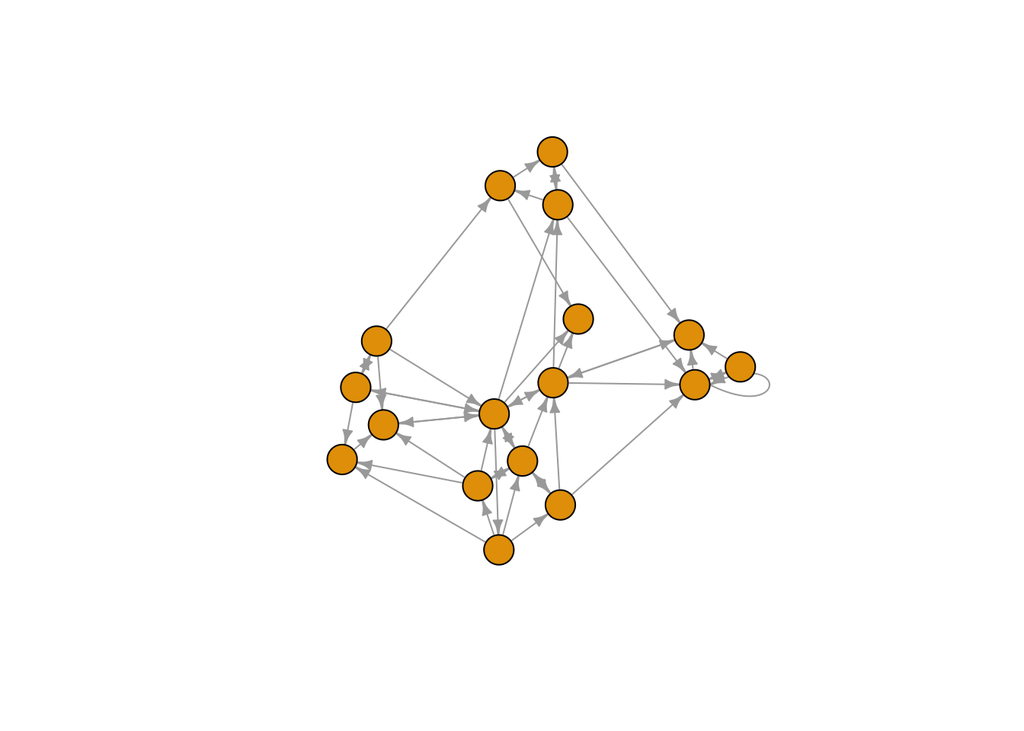

```r
plot(media_network, edge.arrow.size = 0.5, vertex.label = NA)
```

To simplify the network, I will remove the loops.

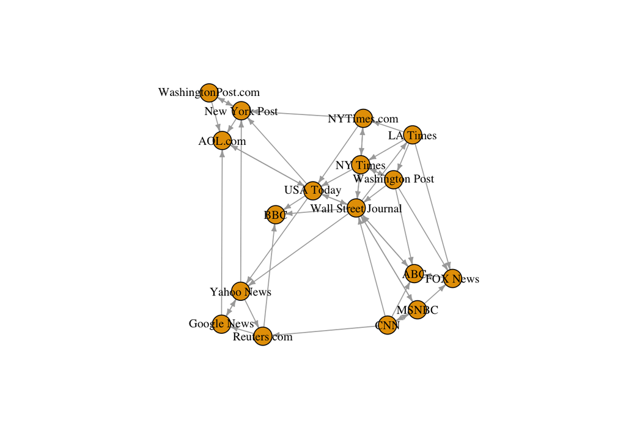

```r
media_network <- simplify(media_network, remove.multiple = F, remove.loops = T)
plot(media_network, edge.arrow.size = 0.4, vertex.label = V(media_network)$media, vertex.label.color = "black", vertex.label.cex = 0.8)
```

**Density**

```r
ecount(media_network)/(vcount(media_network)*(vcount(media_network)-1))
```

```
## [1] 0.1764706
```

The density of the network is 0.176.

**Distribution of Degrees**

```r
degree_distribution(media_network, cumulative = TRUE, mode = "all")
```

```
##  [1] 1.00000000 1.00000000 1.00000000 1.00000000 0.88235294 0.70588235
##  [7] 0.35294118 0.17647059 0.17647059 0.11764706 0.05882353 0.05882353
## [13] 0.05882353 0.05882353
```

##### 2. Run the Girvan-Newman community detection algorithm. Then run the random walk community detection algorithm.

Transform the current network to an undirected network

```r
media_network_new <- as.undirected(media_network, mode = "collapse", edge.attr.comb = list(weight = "sum", "ignore"))
```

**Girvan-Newman community detection algorithm**

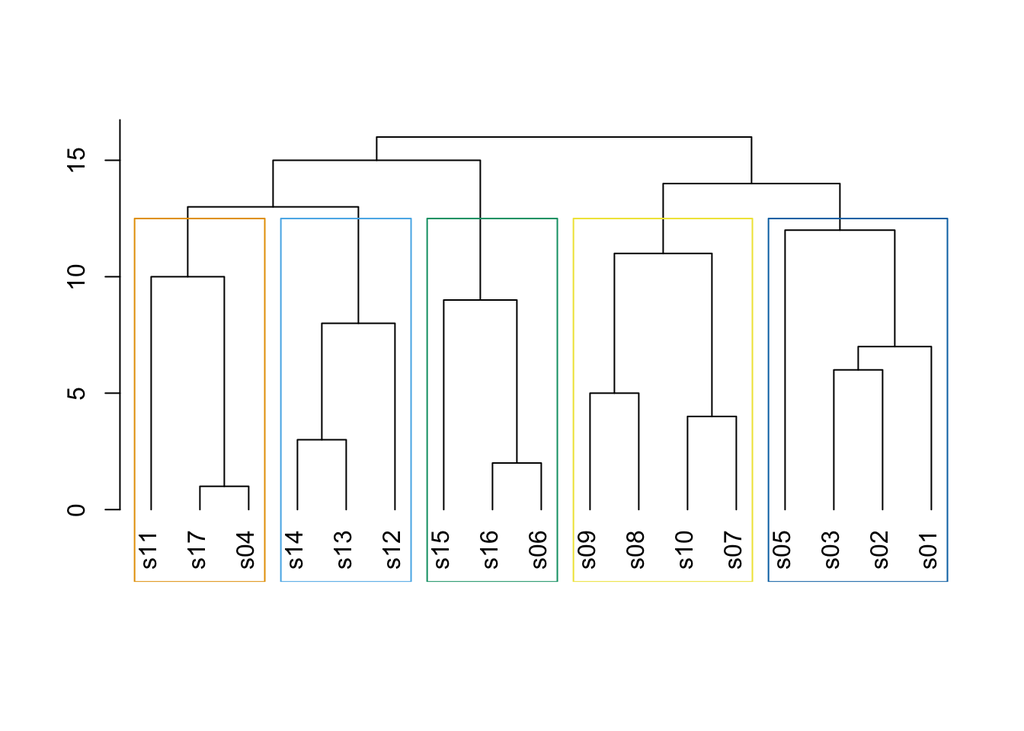

```r
cluster_eb <- cluster_edge_betweenness(media_network_new, bridges = TRUE, modularity = TRUE, membership = TRUE)
dendPlot(cluster_eb, mode = "hclust")
```

```r
cluster_eb
```

```
## IGRAPH clustering edge betweenness, groups: 5, mod: 0.44
## + groups:
##   $`1`
##   [1] "s01" "s02" "s03" "s05"
##
##   $`2`
##   [1] "s04" "s11" "s17"
##
##   $`3`
##   [1] "s06" "s15" "s16"
##
##   $`4`
##   + ... omitted several groups/vertices
```

```r
length(cluster_eb)
```

```
## [1] 5
```

There are five number of communities.

**Random walk community detection algorithm**

```r
random_walk_cd <- walktrap.community(media_network_new, steps = 200, modularity = TRUE)
random_walk_cd
```

```
## IGRAPH clustering walktrap, groups: 4, mod: 0.6
## + groups:
##   $`1`
##   [1] "s01" "s02" "s03" "s04" "s05" "s11" "s15"
##
##   $`2`
##   [1] "s12" "s13" "s14"
##
##   $`3`
##   [1] "s06" "s16" "s17"
##
##   $`4`
##   + ... omitted several groups/vertices
```

```r
length(random_walk_cd)
```

```
## [1] 4
```

There are 4 communities detected.

```r
membership(cluster_eb)
```

```
## s01 s02 s03 s04 s05 s06 s07 s08 s09 s10 s11 s12 s13 s14 s15 s16 s17
##   1   1   1   2   1   3   4   4   4   4   2   5   5   5   3   3   2
```

```r
membership(random_walk_cd)
```

```
## s01 s02 s03 s04 s05 s06 s07 s08 s09 s10 s11 s12 s13 s14 s15 s16 s17
##   1   1   1   1   1   3   4   4   4   4   1   2   2   2   1   3   3
```

The similarity between the two algorithms lies in the categorazation of these groups (12, 13, 14), (10, 09, 08, 07) and (01, 02, 03).

```r
gn <- data.frame(cluster_eb$membership)
rw <- data.frame(random_walk_cd$membership)
dd <- cbind(gn, rw)
cor(dd)
```

```
##                           cluster_eb.membership random_walk_cd.membership
## cluster_eb.membership                 1.0000000                 0.5824647
## random_walk_cd.membership             0.5824647                 1.0000000
```

##### 3. Tell me how many groups each algorithm finds. Analyze how similar the two partitioning algorithms are in terms of putting nodes into groups with each other.

** Girvan-Newman Model**

```r
modularity(cluster_eb)
```

```
## [1] 0.43566
```

The modularity 0.435 is pretty high, which suggests dense communities within community and sparse connections in between communities.

** Random Walk Model**

```r
modularity(random_walk_cd)
```

```
## [1] 0.5972482
```

Here the modularity is 0.597, higher than that of the Girvan-Newman algorithm’s. We prefer a larger value of modulairty when it comes to searching for community structure. So the random walk community detection algorithm performs better here.

##### 4. Visualize the network (either in R or Gephi), coloring the nodes by either Girvan-Newman grouping or the random walk grouping.

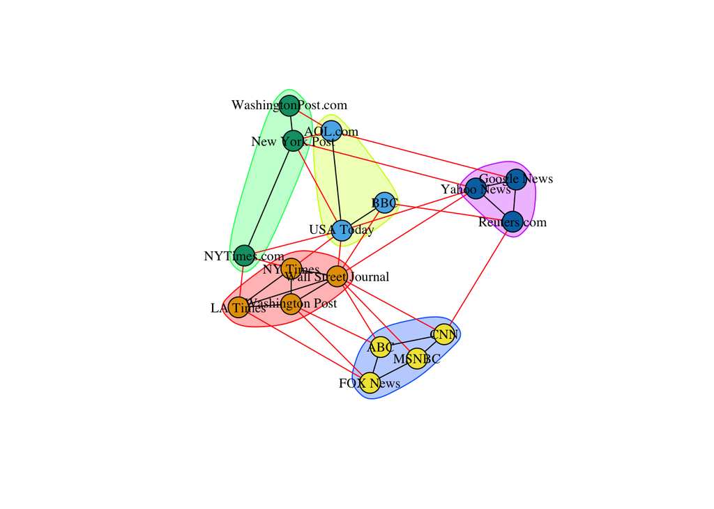

```r
plot(cluster_eb, media_network_new, vertex.label = V(media_network)$media, vertex.label.color = "black", vertex.label.cex = 0.8)
```

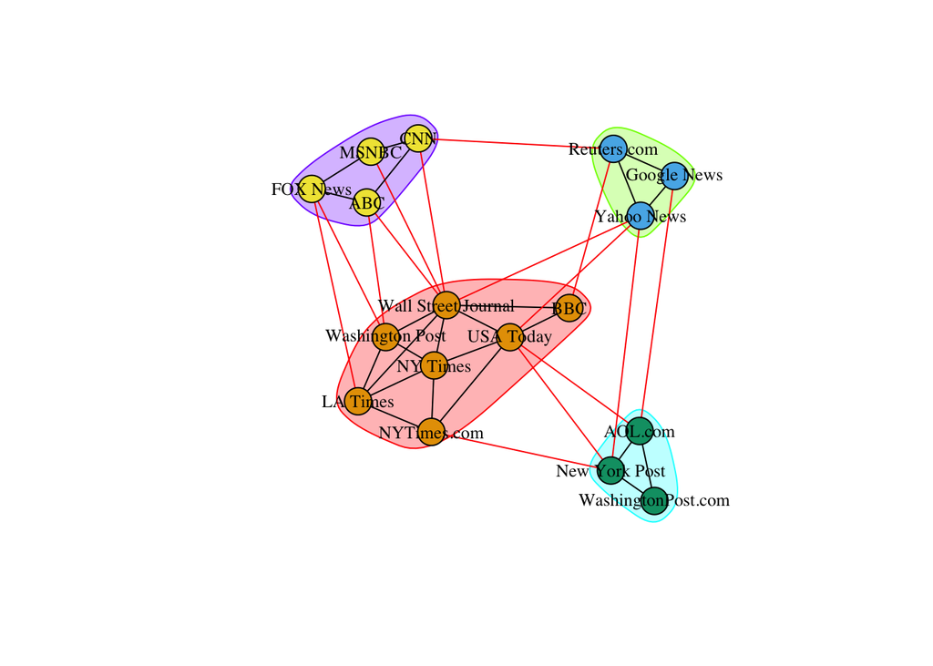

```r
plot(random_walk_cd, media_network_new, vertex.label = V(media_network)$media, vertex.label.color = "black", vertex.label.cex = 0.8)
```

##### 5. Tell me anything else about whether the partitioning makes sense, based on attributes or who the nodes are, and so on.

The partitioning does make some sense, especially that of the random walk community detection algorithm. As we could see from the above graph, FOX News, ABC, MSNBC, CNN are all cable networks. Yahoo News, Reuters and Google News are the news aggregators and heavy on the Internet. The other communities are less obvious but we could see the comparison on their audience size.

```r
rw_new <- data.frame(random_walk_cd$names, random_walk_cd$membership)
rw_new
```

```
##    random_walk_cd.names random_walk_cd.membership
## 1                   s01                         1
## 2                   s02                         1
## 3                   s03                         1
## 4                   s04                         1
## 5                   s05                         1
## 6                   s06                         3
## 7                   s07                         4
## 8                   s08                         4
## 9                   s09                         4
## 10                  s10                         4
## 11                  s11                         1
## 12                  s12                         2
## 13                  s13                         2
## 14                  s14                         2
## 15                  s15                         1
## 16                  s16                         3
## 17                  s17                         3
```

```r
dd_new <- cbind(nodes, rw_new)
dd_new$random_walk_cd.membership <- as.factor(dd_new$random_walk_cd.membership) # convert real number to factor for visualization later
```

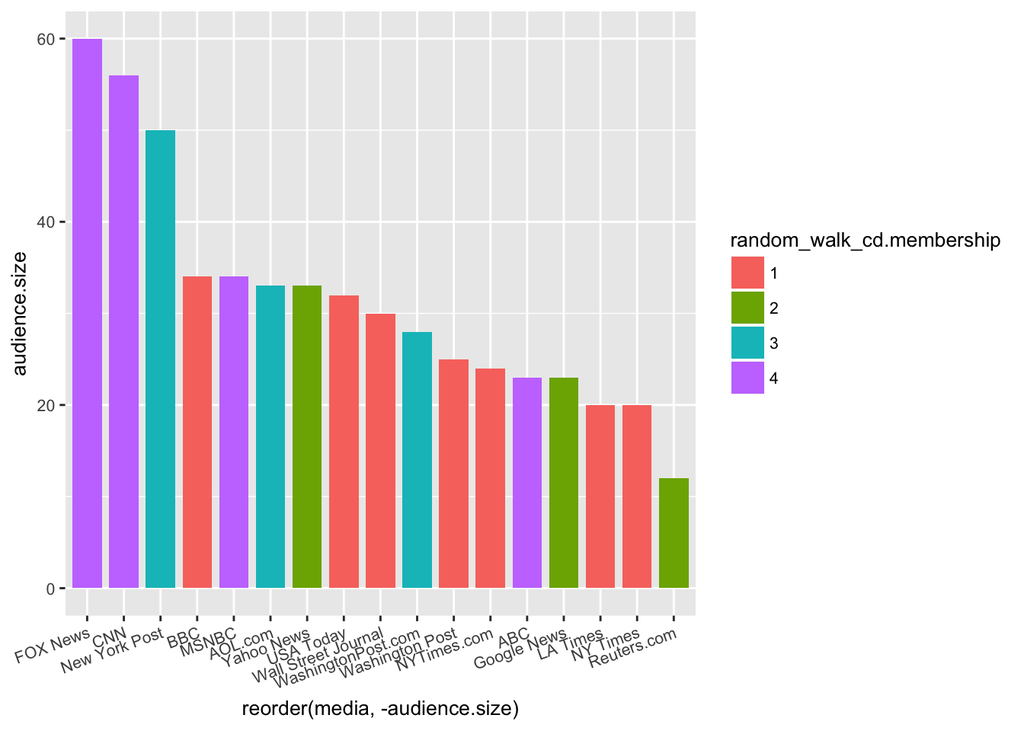

```r
library(ggplot2)
gg <- ggplot(dd_new, aes(x = reorder(media, -audience.size), y = audience.size, fill = random_walk_cd.membership))
gg <- gg + geom_bar(stat = "identity", width = 0.8) +
  theme(text = element_text(size = 10), axis.text.x = element_text(angle = 20, hjust = 1))
gg
```